# 5. The Forecaster’s Toolbox.RMD

## Naïve method

For naïve forecasts, we simply set all forecasts to be the value of the last observation. That is,

$$\hat{y}_{T+h|T}=y_T$$

**This method works remarkably well for many economic and financial time series.**

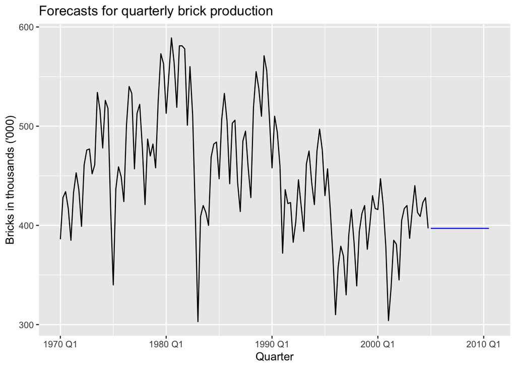

```r
train <- aus_production %>%
  filter_index("1970 Q1" ~ "2004 Q4")
# Fit the models
bricks_fit <- train %>%
  model(
    naive = NAIVE(Bricks),
  )
# Generate forecasts for 23 quarters
bricks_fc <- bricks_fit %>% forecast(h = 23)
# Plot forecasts against actual values
bricks_fc %>%
  autoplot(train, level = NULL) +
  labs(
    y = "Bricks in thousands ('000)",
    title = "Forecasts for quarterly brick production"
  ) +
  guides(colour = guide_legend(title = "Forecast"))
```

## Seasonal naïve method

A similar method is useful for highly seasonal data. In this case, we set each forecast to be equal to the last observed value from the same season of the year (e.g., the same month of the previous year). Formally, the forecast for time T+h is written as

$$\hat{y}_{T+h|T}=y_{T+h-m(k+1)}$$

where m= the seasonal period, and k is the integer part of (h−1)/m (i.e., the number of complete years in the forecast period prior to time T+h).

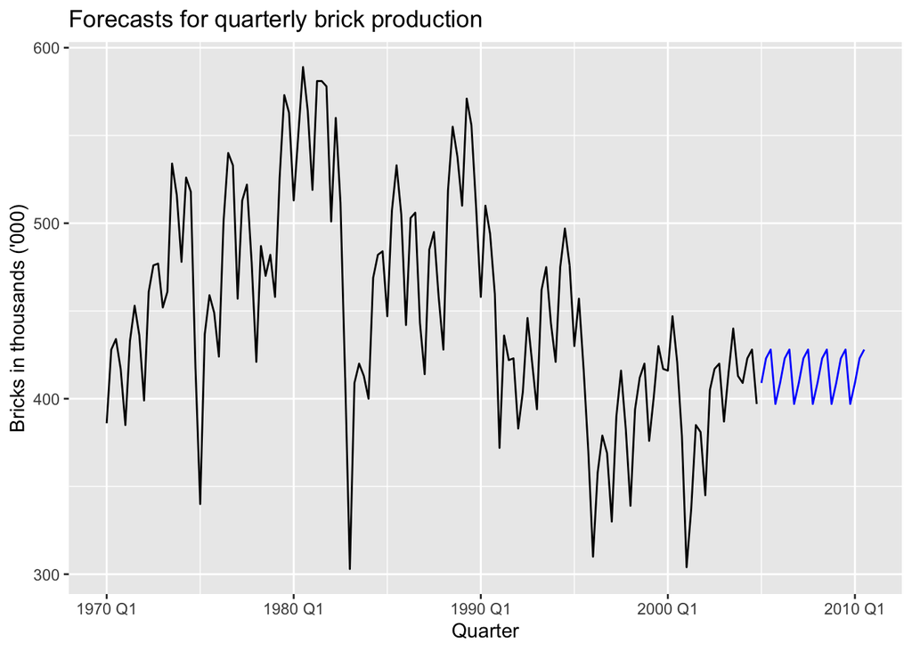

```r
train <- aus_production %>%
  filter_index("1970 Q1" ~ "2004 Q4")
# Fit the models
bricks_fit <- train %>%
  model(
    snaive = SNAIVE(Bricks),
  )
# Generate forecasts for 23 quarters
bricks_fc <- bricks_fit %>% forecast(h = 23)
# Plot forecasts against actual values
bricks_fc %>%
  autoplot(train, level = NULL) +
  labs(
    y = "Bricks in thousands ('000)",
    title = "Forecasts for quarterly brick production"
  ) +
  guides(colour = guide_legend(title = "Forecast"))
```

## Drift method

A variation on the naïve method is to allow the forecasts to increase or decrease over time, where the amount of change over time (called the **drift**) is set to be the average change seen in the historical data. Thus the forecast for time T+h is given by

$$\hat{y}_{T+h|T}=y_T + \frac{h}{T-1}\sum_{t=2}^T(y_t - y_{t-1}) = y_T + h\left( \frac{y_t - y_1}{T-1} \right)$$

This is equivalent to drawing a line between the first and last observations, and extrapolating it into the future.

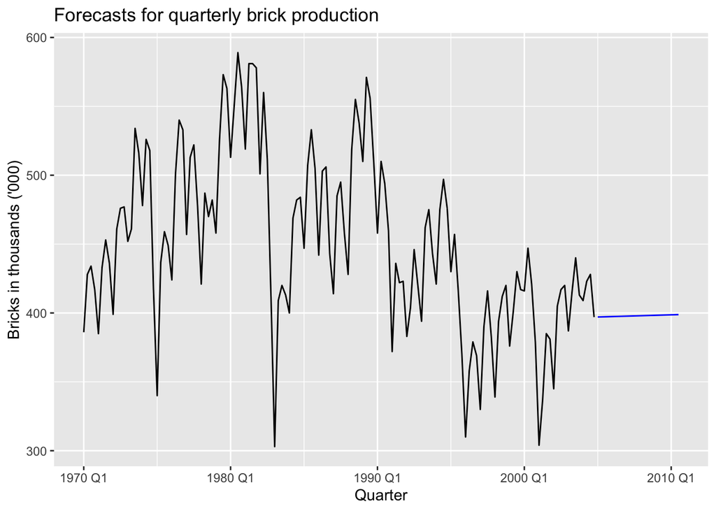

```r
train <- aus_production %>%
  filter_index("1970 Q1" ~ "2004 Q4")
# Fit the models
bricks_fit <- train %>%
  model(
    RW(Bricks ~ drift()),
  )
# Generate forecasts for 23 quarters
bricks_fc <- bricks_fit %>% forecast(h = 23)
# Plot forecasts against actual values
bricks_fc %>%
  autoplot(train, level = NULL) +
  labs(
    y = "Bricks in thousands ('000)",
    title = "Forecasts for quarterly brick production"
  ) +
  guides(colour = guide_legend(title = "Forecast"))
```

Conclusion of section 5.2

## 5.3 Fitted values and residuals

For example, if we use the mean method, the fitted values are given by
$$\hat{y_t} = \hat{c}$$

When the estimate of c involves observations after time t, the fitted values are not true forecasts. On the other hand, naïve or seasonal naïve forecasts do not involve any parameters, and so fitted values are true forecasts in such cases.

## Residuals

The “residuals” in a time series model are what is left over after fitting a model. The residuals are equal to the difference between the observations and the corresponding fitted values:

$$e_t = y_t - \hat{y_t}$$

```r
augment(bricks_fit)
```

```
## # A tsibble: 140 x 6 [1Q]
## # Key:       .model [1]
##    .model               Quarter Bricks .fitted .resid .innov
##    <chr>                  <qtr>  <dbl>   <dbl>  <dbl>  <dbl>
##  1 RW(Bricks ~ drift()) 1970 Q1    386     NA   NA     NA
##  2 RW(Bricks ~ drift()) 1970 Q2    428    386.  41.9   41.9
##  3 RW(Bricks ~ drift()) 1970 Q3    434    428.   5.92   5.92
##  4 RW(Bricks ~ drift()) 1970 Q4    417    434. -17.1  -17.1
##  5 RW(Bricks ~ drift()) 1971 Q1    385    417. -32.1  -32.1
##  6 RW(Bricks ~ drift()) 1971 Q2    433    385.  47.9   47.9
##  7 RW(Bricks ~ drift()) 1971 Q3    453    433.  19.9   19.9
##  8 RW(Bricks ~ drift()) 1971 Q4    436    453. -17.1  -17.1
##  9 RW(Bricks ~ drift()) 1972 Q1    399    436. -37.1  -37.1
## 10 RW(Bricks ~ drift()) 1972 Q2    461    399.  61.9   61.9
## # … with 130 more rows
```

There are three new columns added to the original data:

• `.fitted` contains the fitted values; • `.resid` contains the residuals; • `.innov` contains the “innovation residuals” which, in this case, are identical to the regular residuals.

## 5.4 Residual diagnostics

A good forecasting method will yield innovation residuals with the following properties:

1. The innovation residuals are uncorrelated. If there are correlations between innovation residuals, then there is information left in the residuals which should be used in computing forecasts.
2. The innovation residuals have zero mean. If they have a mean other than zero, then the forecasts are biased.

If either of these properties is not satisfied, then the forecasting method can be modified to give better forecasts. Adjusting for bias is easy: if the residuals have mean m, then simply subtract m from all forecasts and the bias problem is solved. Fixing the correlation problem is harder, and we will not address it until Chapter 10.

3. The innovation residuals have constant variance. This is known as “homoscedasticity”.
4. The innovation residuals are normally distributed.

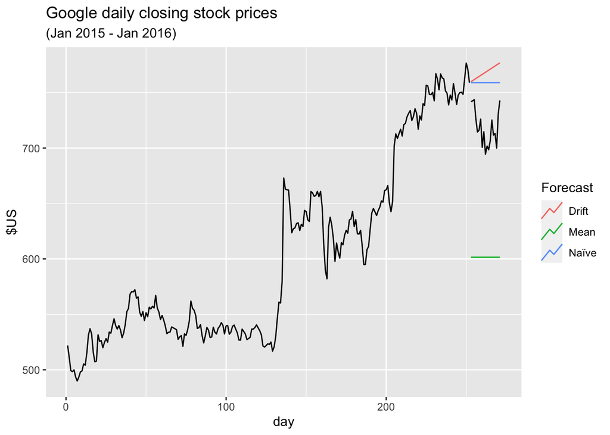

```r
google_stock <- gafa_stock %>%
  filter(Symbol == "GOOG", year(Date) >= 2015) %>%
  mutate(day = row_number()) %>%
  update_tsibble(index = day, regular = TRUE)

google_2015 <- google_stock %>% filter(year(Date) == 2015)
# Fit the models
google_fit <- google_2015 %>%
  model(
    Mean = MEAN(Close),
    `Naïve` = NAIVE(Close),
    Drift = NAIVE(Close ~ drift())
  )
# Produce forecasts for the trading days in January 2016
google_jan_2016 <- google_stock %>%
  filter(yearmonth(Date) == yearmonth("2016 Jan"))
google_fc <- google_fit %>%
  forecast(new_data = google_jan_2016)
# Plot the forecasts
google_fc %>%
  autoplot(google_2015, level = NULL) +
  autolayer(google_jan_2016, Close, colour = "black") +
  labs(y = "$US",
       title = "Google daily closing stock prices",
       subtitle = "(Jan 2015 - Jan 2016)") +
  guides(colour = guide_legend(title = "Forecast"))
```

The residuals obtained from forecasting this series using the naïve method are shown in Figure 5.10. The large positive residual is a result of the unexpected price jump in July.

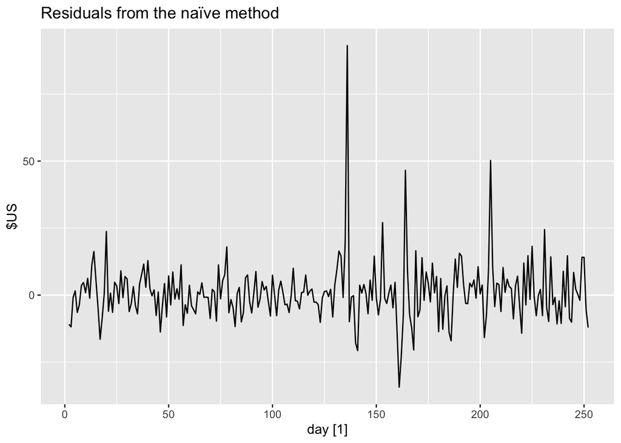

```r
aug <- google_2015 %>%
  model(NAIVE(Close)) %>%
  augment()
autoplot(aug, .innov) +
  labs(y = "$US",
       title = "Residuals from the naïve method")
```

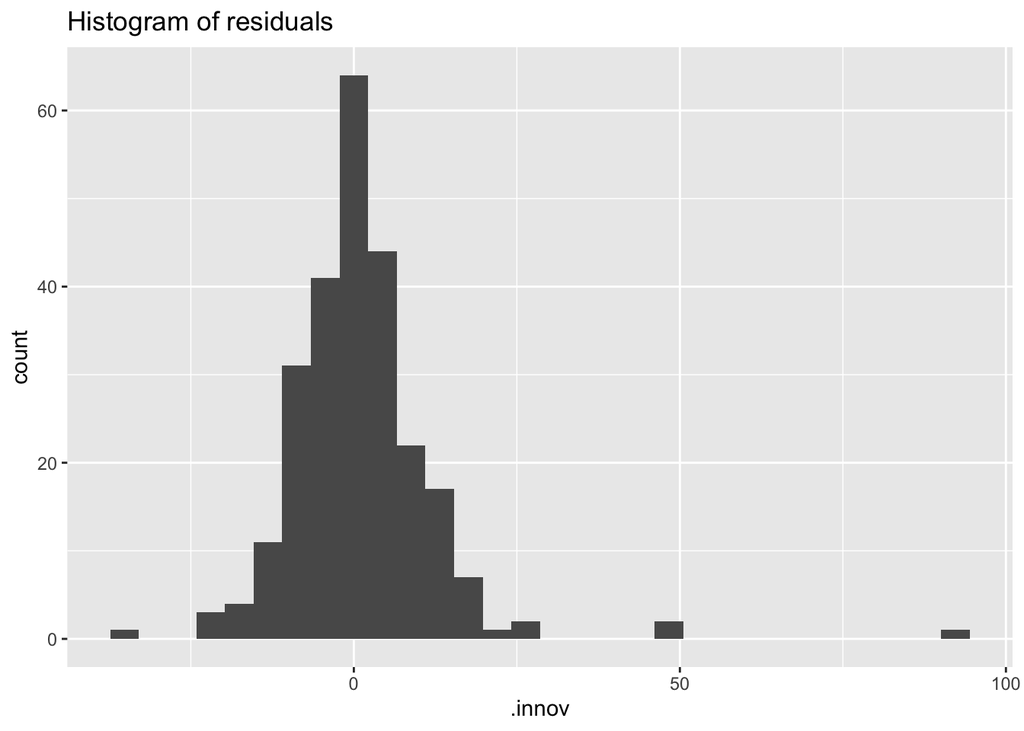

```r
aug %>%
  ggplot(aes(x = .innov)) +
  geom_histogram() +
  labs(title = "Histogram of residuals")
```

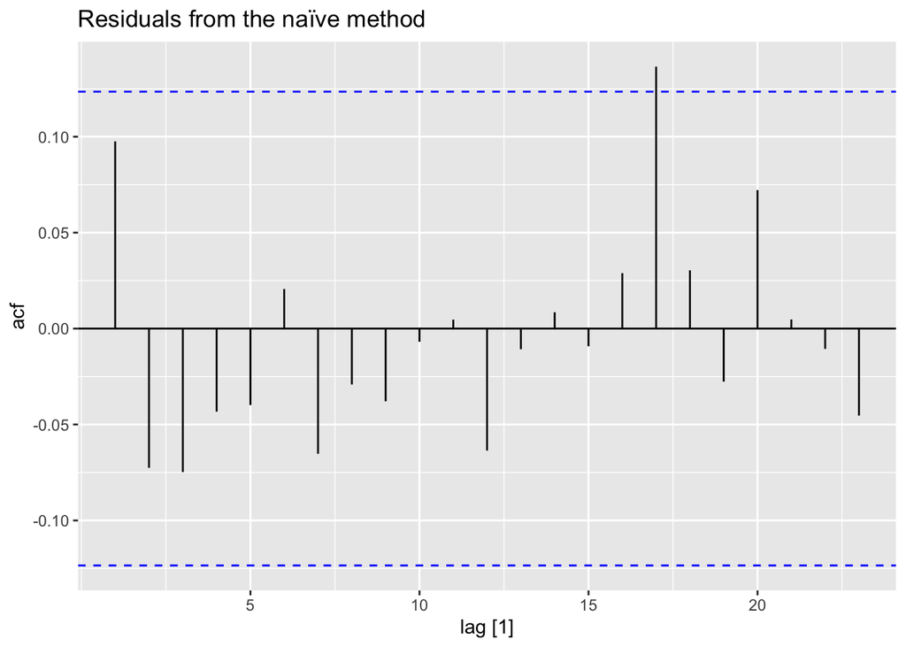

```r
aug %>%
  ACF(.innov) %>%
  autoplot() +
  labs(title = "Residuals from the naïve method")
```

A convenient shortcut for producing these residual diagnostic graphs is the gg_tsresiduals() function, which will produce a time plot, ACF plot and histogram of the residuals.

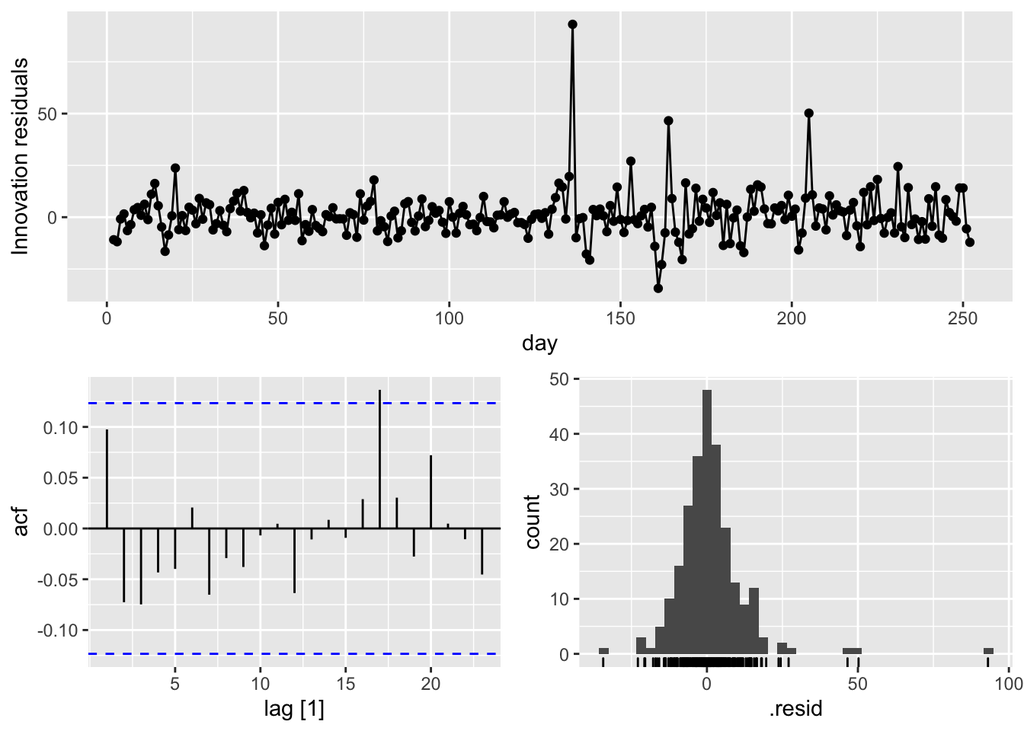

```r
google_2015 %>%
  model(NAIVE(Close)) %>%
  gg_tsresiduals()
```

## Portmanteau tests for autocorrelation

In addition to looking at the ACF plot, we can also do a more formal test for autocorrelation by considering a whole set of rk values as a group, rather than treating each one separately.

the **Ljun-Box test**, based on

$$Q^*=T(T+2)\sum_{k=1}^\ell(T-k)^{-1}r^2_k$$

For the Google stock price example, the naïve method has no parameters, so K=0 in that case also. In the following code, lag=ℓ and dof=K.

```r
aug %>% features(.innov, box_pierce, lag = 10, dof = 0)
```

```
## # A tibble: 1 × 4
##   Symbol .model       bp_stat bp_pvalue
##   <chr>  <chr>          <dbl>     <dbl>
## 1 GOOG   NAIVE(Close)    7.74     0.654
```

```r
aug %>% features(.innov, ljung_box, lag = 10, dof = 0)
```

```
## # A tibble: 1 × 4
##   Symbol .model       lb_stat lb_pvalue
##   <chr>  <chr>          <dbl>     <dbl>
## 1 GOOG   NAIVE(Close)    7.91     0.637
```

For both Q and Q∗, the results are not significant (i.e., the p-values are relatively large). Thus, we can conclude that the residuals are not distinguishable from a white noise series.

An alternative simple approach that may be appropriate for forecasting the Google daily closing stock price is the drift method. The `tidy()` function shows the one estimated parameter, the drift coefficient, measuring the average daily change observed in the historical data.

```r
fit <- google_2015 %>% model(RW(Close ~ drift()))
tidy(fit)
```

```
## # A tibble: 1 × 7
##   Symbol .model              term  estimate std.error statistic p.value
##   <chr>  <chr>               <chr>    <dbl>     <dbl>     <dbl>   <dbl>
## 1 GOOG   RW(Close ~ drift()) b        0.944     0.705      1.34   0.182
```

Applying the Ljung-Box test, we set K=1 to account for the estimated parameter.

```r
augment(fit) %>% features(.innov, ljung_box, lag = 10, dof = 1)
```

```
## # A tibble: 1 × 4
##   Symbol .model              lb_stat lb_pvalue
##   <chr>  <chr>                 <dbl>     <dbl>
## 1 GOOG   RW(Close ~ drift())    7.91     0.543
```

As with the naïve method, the residuals from the drift method are indistinguishable from a white noise series.

Conclusion of section 5.4

# 5.5 Distribution forecasts and prediction intervals

**If we only produce point forecasts, there is no way of telling how accurate the forecasts are. However, if we also produce prediction intervals, then it is clear how much uncertainty is associated with each forecast. For this reason, point forecasts can be of almost no value without the accompanying prediction intervals.**

A prediction interval gives an interval within which we expect
$$y_t$$
to lie within a specified probability. For example, assuming that distribution of future observations is normal, a 95% prediction interval for the h-step forecast is:

$$\hat{y}_{T+h|T}\pm 1.96\hat{\sigma}_h$$

## One-step prediction intervals

When forecasting one step ahead, the standard deviation of the forecast distrubtion can be estimated using the standard deviation of the residuals given by:

$$\hat{\sigma} = \sqrt{\frac{1}{T - K}\sum_{t=1}^Te^2_t}$$

## Multi-step prediction intervals

A common feature of prediction intervals is that they usually increase in length as the forecast horizon increases. The further ahead we forecast, the more uncertainty is associated with the forecast, and thus the wider the prediction intervals. That is, σh usually increases with h

(although there are some non-linear forecasting methods which do not have this property).

To produce a prediction interval, it is necessary to have an estimate of σh . As already noted, for one-step forecasts (h=1), Equation (5.1) provides a good estimate of the forecast standard deviation σ1. For multi-step forecasts, a more complicated method of calculation is required. These calculations assume that the residuals are uncorrelated.

| Benchmark Method | h-step forecast standard deviation |
| --- | --- |
| Mean | $$\hat{\sigma}_h = \hat{\sigma}\sqrt{1 + \frac{1}{T}}$$ |
| Naïve | $$\hat{\sigma}_h = \hat{\sigma}\sqrt{h}$$ |
| Seasonal naïve | $$\hat{\sigma}_h = \hat{\sigma}\sqrt{k + 1}$$ |
| Drift | $$\hat{\sigma}_h = \hat{\sigma}\sqrt{h(1 + \frac{h}{T})}$$ |

Prediction intervals can easily be computed for you when using the `fable` package. For example here is the output when using the naïve method for the Google stock price:

```r
google_2015 %>%
  model(NAIVE(Close)) %>%
  forecast(h = 10) %>%
  hilo()
```

```
## # A tsibble: 10 x 7 [1]
## # Key:       Symbol, .model [1]
##    Symbol .model         day        Close .mean                  `80%`
##    <chr>  <chr>        <dbl>       <dist> <dbl>                 <hilo>
##  1 GOOG   NAIVE(Close)   253  N(759, 125)  759. [744.5400, 773.2200]80
##  2 GOOG   NAIVE(Close)   254  N(759, 250)  759. [738.6001, 779.1599]80
##  3 GOOG   NAIVE(Close)   255  N(759, 376)  759. [734.0423, 783.7177]80
##  4 GOOG   NAIVE(Close)   256  N(759, 501)  759. [730.1999, 787.5601]80
##  5 GOOG   NAIVE(Close)   257  N(759, 626)  759. [726.8147, 790.9453]80
##  6 GOOG   NAIVE(Close)   258  N(759, 751)  759. [723.7543, 794.0058]80
##  7 GOOG   NAIVE(Close)   259  N(759, 876)  759. [720.9399, 796.8202]80
##  8 GOOG   NAIVE(Close)   260 N(759, 1002)  759. [718.3203, 799.4397]80
##  9 GOOG   NAIVE(Close)   261 N(759, 1127)  759. [715.8599, 801.9001]80
## 10 GOOG   NAIVE(Close)   262 N(759, 1252)  759. [713.5329, 804.2272]80
## # … with 1 more variable: 95% <hilo>
```

```r
google_2015 %>%
  model(NAIVE(Close)) %>%
  forecast(h = 10) %>%
  hilo(level = 0.90)
```

```
## # A tsibble: 10 x 6 [1]
## # Key:       Symbol, .model [1]
##    Symbol .model         day        Close .mean                  `0.9%`
##    <chr>  <chr>        <dbl>       <dist> <dbl>                  <hilo>
##  1 GOOG   NAIVE(Close)   253  N(759, 125)  759. [758.7538, 759.0062]0.9
##  2 GOOG   NAIVE(Close)   254  N(759, 250)  759. [758.7015, 759.0585]0.9
##  3 GOOG   NAIVE(Close)   255  N(759, 376)  759. [758.6614, 759.0986]0.9
##  4 GOOG   NAIVE(Close)   256  N(759, 501)  759. [758.6276, 759.1324]0.9
##  5 GOOG   NAIVE(Close)   257  N(759, 626)  759. [758.5978, 759.1622]0.9
##  6 GOOG   NAIVE(Close)   258  N(759, 751)  759. [758.5708, 759.1892]0.9
##  7 GOOG   NAIVE(Close)   259  N(759, 876)  759. [758.5461, 759.2139]0.9
##  8 GOOG   NAIVE(Close)   260 N(759, 1002)  759. [758.5230, 759.2370]0.9
##  9 GOOG   NAIVE(Close)   261 N(759, 1127)  759. [758.5013, 759.2587]0.9
## 10 GOOG   NAIVE(Close)   262 N(759, 1252)  759. [758.4809, 759.2791]0.9
```

When plotted, the prediction intervals are shown as shaded regions, with the strength of colour indicating the probability associated with the interval. Again, 80% and 95% intervals are shown by default, with other options available via the level argument.

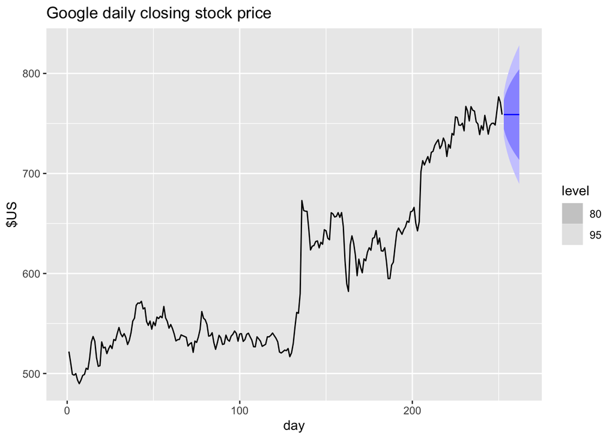

```r
google_2015 %>%
  model(NAIVE(Close)) %>%
  forecast(h = 10) %>%
  autoplot(google_2015) +
  labs(title="Google daily closing stock price", y = "$US")
```

## Prediction from bootstrapped residuals

A one step error is defined as:

$$e_t = y_t - \hat{y}_{t|t-1}$$
Simple algebra yields:
$$y_t = \hat{y}_{t|t-1} + e_t$$

We can simulate the next observation of a time series using:

$$y_{T+1} = \hat{y}_{T+1|t} + e_{T+1}$$

Doing this repeatedly, we obtain many possible futures. To see some of them, we can use the `generate()` function:

```r
fit <-google_2015 %>%
  model(NAIVE(Close))
sim <- fit %>% generate(h = 30, times = 5, bootstrap = TRUE)
```

We can plot the five possible futures, as follows:

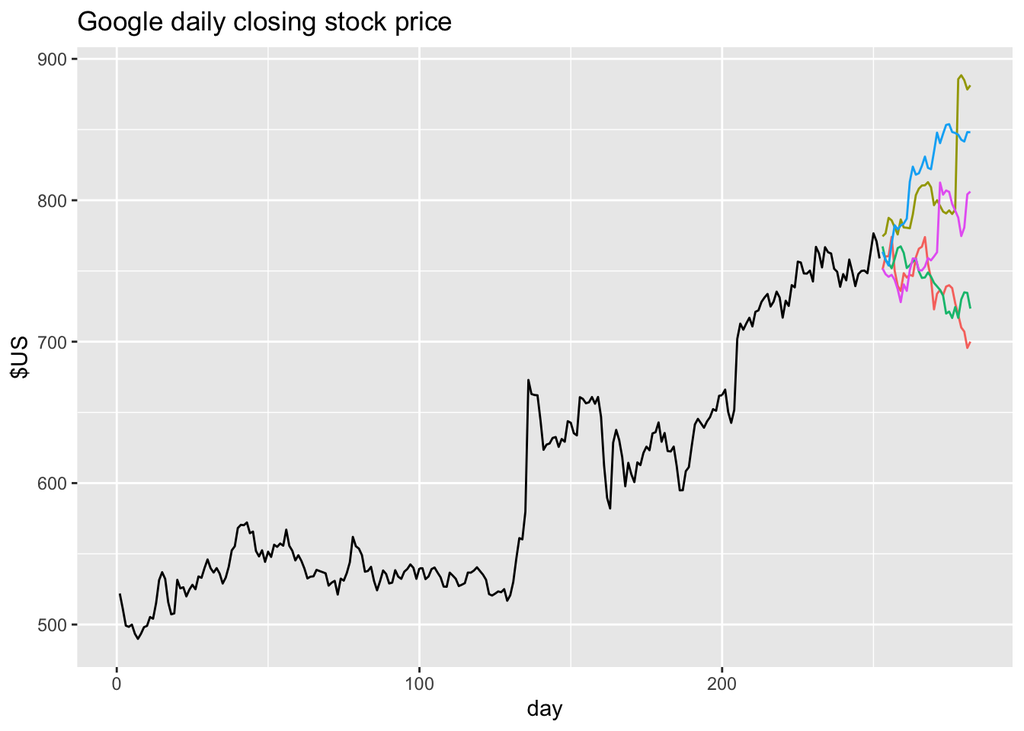

```r
google_2015 %>%
  ggplot(aes(x = day)) +
  geom_line(aes(y = Close)) +
  geom_line(aes(y = .sim, colour = as.factor(.rep)),
            data = sim) +
  labs(title = "Google daily closing stock price", y = "$US") +
  guides(colour = "none")
```

Then we can compute prediction intervals by calculating percentiles of the future sample paths for each forecast horizon. The result is called a **bootstrapped** prediction interval. The name “bootstrap” is a reference to pulling ourselves up by our bootstraps, because the process allows us to measure future uncertainty by only using the historical data.

This is all built into the `forecast()` function so you do not need to call `generate()` directly.

```r
fc <- fit %>% forecast(h = 30, bootstrap = TRUE)
fc
```

```
## # A fable: 30 x 5 [1]
## # Key:     Symbol, .model [1]
##    Symbol .model         day        Close .mean
##    <chr>  <chr>        <dbl>       <dist> <dbl>
##  1 GOOG   NAIVE(Close)   253 sample[5000]  759.
##  2 GOOG   NAIVE(Close)   254 sample[5000]  759.
##  3 GOOG   NAIVE(Close)   255 sample[5000]  759.
##  4 GOOG   NAIVE(Close)   256 sample[5000]  759.
##  5 GOOG   NAIVE(Close)   257 sample[5000]  759.
##  6 GOOG   NAIVE(Close)   258 sample[5000]  758.
##  7 GOOG   NAIVE(Close)   259 sample[5000]  758.
##  8 GOOG   NAIVE(Close)   260 sample[5000]  758.
##  9 GOOG   NAIVE(Close)   261 sample[5000]  758.
## 10 GOOG   NAIVE(Close)   262 sample[5000]  758.
## # … with 20 more rows
```

Notice that the forecast distribution is now represented as a simulation with 5000 sample paths. Because there is no normality assumption, the prediction intervals are not symmetric.

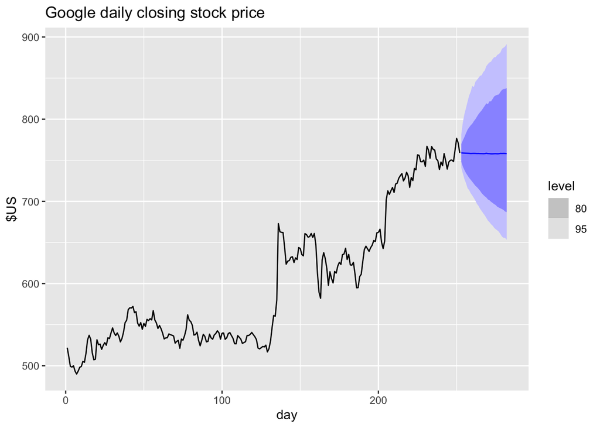

```r
autoplot(fc, google_2015) +
  labs(title = "Google daily closing stock price", y = "$US")
```

Completion through section 5.5

## Forecasting using transformations

Some common transformations which can be used when modelling were discussed in Section 3.1. When forecasting from a model with transformations, we first produce forecasts of the transformed data. Then, we need to reverse the transformation (or back-transform) to obtain forecasts on the original scale. For Box-Cox transformations given by (3.1), the reverse transformation is given by:

$$y_{t} =
\begin{cases}
\exp(w_{t}) & \text{if $\lambda=0$};\\
\text{sign}(\lambda w_t+1)|\lambda w_t+1|^{1/\lambda} & \text{otherwise}.
\end{cases}$$

## Bias adjustments

One issue with using mathematical transformations such as Box-Cox transformations is that the back-transformed point forecast will not be the mean of the forecast distribution. In fact, it will usually be the median of the forecast distribution (assuming that the distribution on the transformed space is symmetric). For many purposes, this is acceptable, although the mean is usually preferable. For example, you may wish to add up sales forecasts from various regions to form a forecast for the whole country. But medians do not add up, whereas means do.

For a Box-Cos transformation, the back-transformed mean is given (approximately) by:

$$\hat{y}_{T+h|T} =
\begin{cases}
\exp(\hat{w}_{T+h|T})\left[1 + \frac{\sigma_h^2}{2}\right] & \text{if $\lambda=0$;}\\
(\lambda \hat{w}_{T+h|T}+1)^{1/\lambda}\left[1 + \frac{\sigma_h^2(1-\lambda)}{2(\lambda \hat{w}_{T+h|T}+1)^{2}}\right] & \text{otherwise;}
\end{cases}$$

The difference between the simple back-transformed forecast given by (5.2) and the mean given by (5.3) is called the **bias**. When we use the mean, rather than the median, we say the point forecasts have been **bias-adjusted**.

To see how much difference this bias-adjustment makes, consider the following example, where we forecast the average annual price of eggs using the drift method with a log transformation (λ=0). The log transformation is useful in this case to ensure the forecasts and the prediction intervals stay positive.

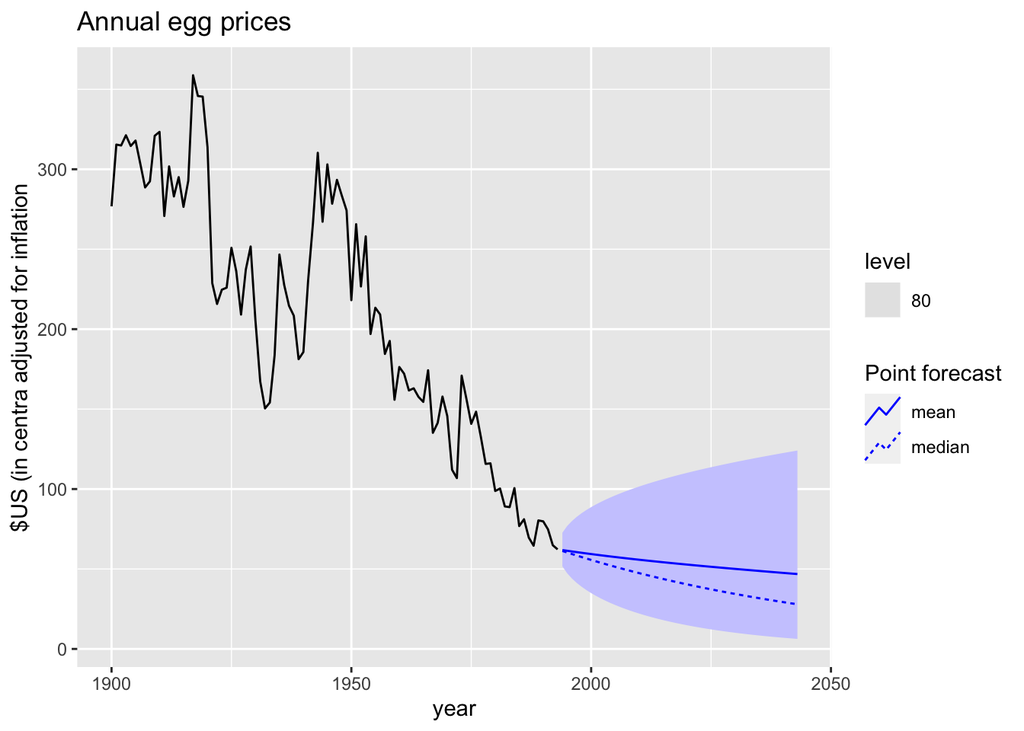

```r
prices %>%
  filter(!is.na(eggs)) %>%
  model(RW(log(eggs) ~ drift())) %>%
  forecast(h = 50) %>%
  autoplot(prices %>% filter(!is.na(eggs)),
           level = 80, point_forecast = lst(mean, median)) +
  labs(title = "Annual egg prices",
       y = "$US (in centra adjusted for inflation")
```

The dashed line in Figure 5.17 shows the forecast medians while the solid line shows the forecast means. Notice how the skewed forecast distribution pulls up the forecast distribution’s mean; this is a result of the added term from the bias adjustment.

Bias-adjusted forecast means are automatically computed in the fable package. The forecast median (the point forecast prior to bias adjustment) can be obtained using the median() function on the distribution column.

Completion of section 5.6

## Forecasting with decomposition

Assuming additive decomposition, the decomposed time series can be written as:

$$y_t = \hat{S_t} + \hat{A_t}$$

If a multiplicative decomposition has been used, we can write:

$$y_y = \hat{S_t}\hat{A_t}$$

To forecast a decomposed time series, we forecast the seasonal component, ${S_t}$, and the seasonally adjusted component ${A_t}$, separately.

## Example: Employment in the US Retail Sector

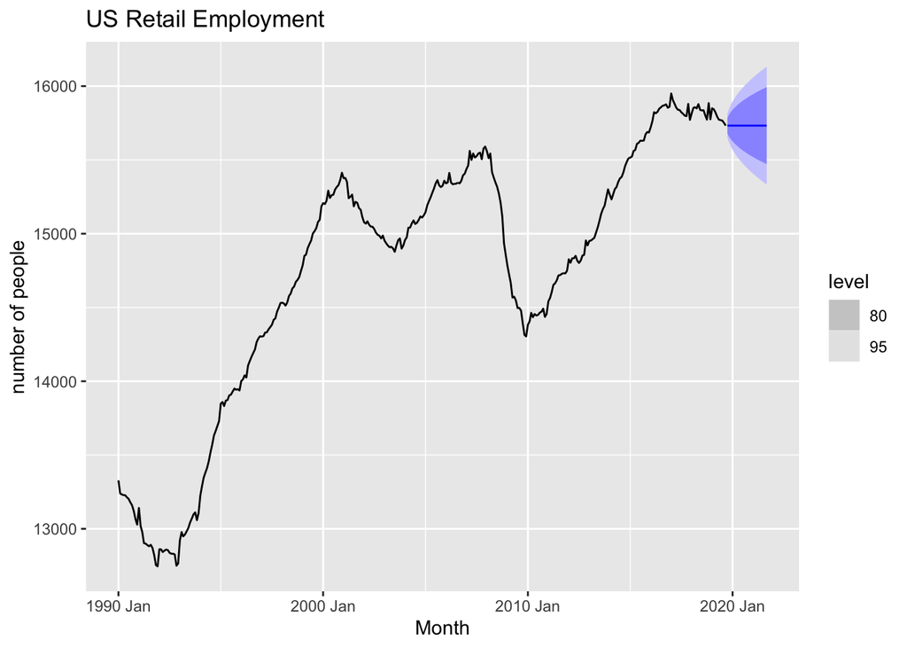

```r
us_retail_employment <- us_employment %>%
  filter(year(Month) >= 1990, Title == "Retail Trade")
dcmp <- us_retail_employment %>%
  model(STL(Employed~trend(window = 7), robust = TRUE)) %>%
  components() %>%
  select(-.model)
dcmp %>%
  model(NAIVE(season_adjust)) %>%
  forecast() %>%
  autoplot(dcmp) +
  labs(y = "number of people",
       title = "US Retail Employment")
```

Figure 5.18 shows naïve forecasts of the seasonally adjusted US retail employment data. These are then “reseasonalised” by adding in the seasonal naïve forecasts of the seasonal component.

This is made easy with the `decomposition_model()` function, which allows you to compute forecasts via any additive decomposition, using other model functions to forecast each of the decomposition’s components. Seasonal components of the model will be forecast automatically using `SNAIVE()` if a different model isn’t specified. The function will also do the reseasonalising for you, ensuring that the resulting forecasts of the original data are obtained. These are shown in Figure 5.19.

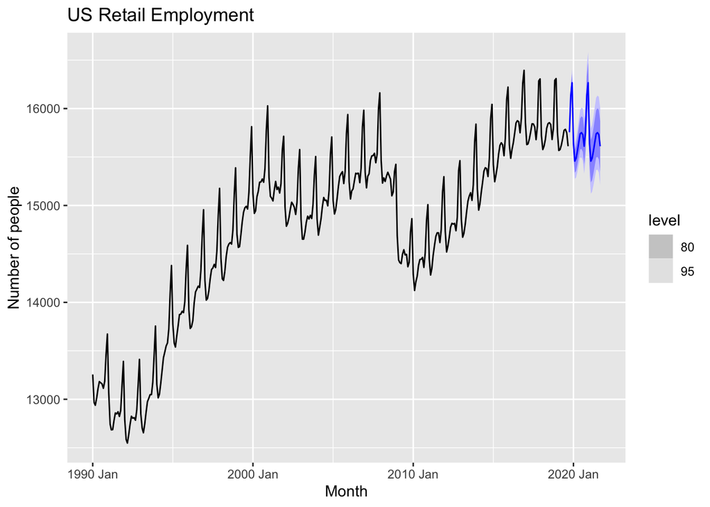

```r
fit_dcmp <- us_retail_employment %>%
  model(stlf = decomposition_model(
    STL(Employed ~ trend(window = 7), robust = TRUE),
    NAIVE(season_adjust)
  ))
fit_dcmp %>%
  forecast() %>%
  autoplot(us_retail_employment) +
  labs(y = "Number of people",
       title = "US Retail Employment")
```

The prediction intervals shown in this graph are constructed in the same way as the point forecasts. That is, the upper and lower limits of the prediction intervals on the seasonally adjusted data are “reseasonalised” by adding in the forecasts of the seasonal component.

The ACF of the residuals shown in Figure 5.20, display significant autocorrelations. These are due to the naïve method not capturing the changing trend in the seasonally adjusted series.

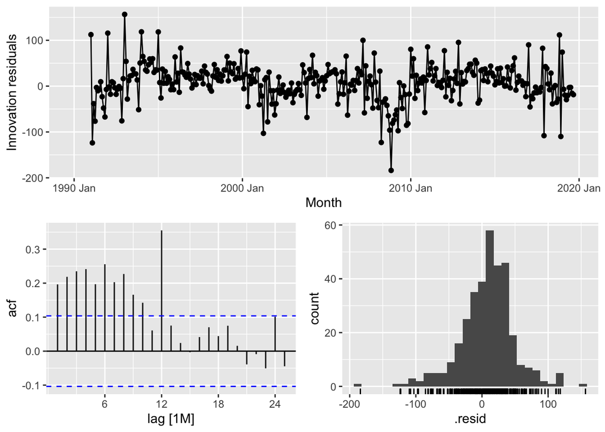

```r
fit_dcmp %>% gg_tsresiduals()
```

Completion through section 5.7

## 5.8 Evaluating point forecast accuracy

### Training and test sets

When choosing models, it is common practice to separate the available data into two portions, training and test data, where the training data is used to estimate any parameters of a forecasting method and the test data is used to evaluate its accuracy. Because the test data is not used in determining the forecasts, it should provide a reliable indication of how well the model is likely to forecast on new data.

The size of the test set is typically about 20% of the total sample, although this value depends on how long the sample is and how far ahead you want to forecast. The test set should ideally be at least as large as the maximum forecast horizon required. The following points should be noted.

• A model which fits the training data well will not necessarily forecast well. • A perfect fit can always be obtained by using a model with enough parameters. • Over-fitting a model to data is just as bad as failing to identify a systematic pattern in the data.

### Functions to subset a time series

The filter() function is useful when extracting a portion of a time series, such as we need when creating training and test sets. When splitting data into evaluation sets, filtering the index of the data is particularly useful. For example,

```r
aus_production %>% filter(year(Quarter)>= 1995)
```

```
## # A tsibble: 62 x 7 [1Q]
##    Quarter  Beer Tobacco Bricks Cement Electricity   Gas
##      <qtr> <dbl>   <dbl>  <dbl>  <dbl>       <dbl> <dbl>
##  1 1995 Q1   426    4714    430   1626       41768   131
##  2 1995 Q2   408    3939    457   1703       43686   167
##  3 1995 Q3   416    6137    417   1733       46022   181
##  4 1995 Q4   520    4739    370   1545       42800   145
##  5 1996 Q1   409    4275    310   1526       43661   133
##  6 1996 Q2   398    5239    358   1593       44707   162
##  7 1996 Q3   398    6293    379   1706       46326   184
##  8 1996 Q4   507    5575    369   1699       43346   146
##  9 1997 Q1   432    4802    330   1511       43938   135
## 10 1997 Q2   398    5523    390   1785       45828   171
## # … with 52 more rows
```

Equivalently,

```r
aus_production %>% filter_index("1995 Q1" ~.,)
```

```
## # A tsibble: 62 x 7 [1Q]
##    Quarter  Beer Tobacco Bricks Cement Electricity   Gas
##      <qtr> <dbl>   <dbl>  <dbl>  <dbl>       <dbl> <dbl>
##  1 1995 Q1   426    4714    430   1626       41768   131
##  2 1995 Q2   408    3939    457   1703       43686   167
##  3 1995 Q3   416    6137    417   1733       46022   181
##  4 1995 Q4   520    4739    370   1545       42800   145
##  5 1996 Q1   409    4275    310   1526       43661   133
##  6 1996 Q2   398    5239    358   1593       44707   162
##  7 1996 Q3   398    6293    379   1706       46326   184
##  8 1996 Q4   507    5575    369   1699       43346   146
##  9 1997 Q1   432    4802    330   1511       43938   135
## 10 1997 Q2   398    5523    390   1785       45828   171
## # … with 52 more rows
```

```r
# This is equivalent to the previous data set
```

Another useful function is slice(), which allows the use of indices to choose a subset from each group. For example,

```r
aus_production %>%
  slice(n()-19:0)
```

```
## # A tsibble: 20 x 7 [1Q]
##    Quarter  Beer Tobacco Bricks Cement Electricity   Gas
##      <qtr> <dbl>   <dbl>  <dbl>  <dbl>       <dbl> <dbl>
##  1 2005 Q3   408      NA     NA   2340       56043   221
##  2 2005 Q4   482      NA     NA   2265       54992   180
##  3 2006 Q1   438      NA     NA   2027       57112   171
##  4 2006 Q2   386      NA     NA   2278       57157   224
##  5 2006 Q3   405      NA     NA   2427       58400   233
##  6 2006 Q4   491      NA     NA   2451       56249   192
##  7 2007 Q1   427      NA     NA   2140       56244   187
##  8 2007 Q2   383      NA     NA   2362       55036   234
##  9 2007 Q3   394      NA     NA   2536       59806   245
## 10 2007 Q4   473      NA     NA   2562       56411   205
## 11 2008 Q1   420      NA     NA   2183       59118   194
## 12 2008 Q2   390      NA     NA   2558       56660   229
## 13 2008 Q3   410      NA     NA   2612       64067   249
## 14 2008 Q4   488      NA     NA   2373       59045   203
## 15 2009 Q1   415      NA     NA   1963       58368   196
## 16 2009 Q2   398      NA     NA   2160       57471   238
## 17 2009 Q3   419      NA     NA   2325       58394   252
## 18 2009 Q4   488      NA     NA   2273       57336   210
## 19 2010 Q1   414      NA     NA   1904       58309   205
## 20 2010 Q2   374      NA     NA   2401       58041   236
```

will extract the last 20 observations (five years)

Slice also works with groups, making it possible to subset observations from each key. For example:

```r
aus_retail %>%
  group_by(State, Industry) %>%
  slice(1:12)
```

```
## # A tsibble: 1,824 x 5 [1M]
## # Key:       State, Industry [152]
## # Groups:    State, Industry [152]
##    State                        Industry           `Series ID`    Month Turnover
##    <chr>                        <chr>              <chr>          <mth>    <dbl>
##  1 Australian Capital Territory Cafes, restaurant… A3349849A   1982 Apr      4.4
##  2 Australian Capital Territory Cafes, restaurant… A3349849A   1982 May      3.4
##  3 Australian Capital Territory Cafes, restaurant… A3349849A   1982 Jun      3.6
##  4 Australian Capital Territory Cafes, restaurant… A3349849A   1982 Jul      4
##  5 Australian Capital Territory Cafes, restaurant… A3349849A   1982 Aug      3.6
##  6 Australian Capital Territory Cafes, restaurant… A3349849A   1982 Sep      4.2
##  7 Australian Capital Territory Cafes, restaurant… A3349849A   1982 Oct      4.8
##  8 Australian Capital Territory Cafes, restaurant… A3349849A   1982 Nov      5.4
##  9 Australian Capital Territory Cafes, restaurant… A3349849A   1982 Dec      6.9
## 10 Australian Capital Territory Cafes, restaurant… A3349849A   1983 Jan      3.8
## # … with 1,814 more rows
```

will subset the first year of data from each time series in the data.

## Forecast errors

A forecast “error” is the difference between an observed value and its forecast. Here “error” does not mean mistake, it means the unpredictable part of an observation. It can be written as:

$$e_{T+h} = y_{T+h} - \hat{y}_{T+h|T}$$

where the training data is given by $\left\{y_1,...y_t \right\}$ and the test data is given by $\left\{ y_{T+1}, y_{T+2}, ...\right\}$

The two most commonly used scale-dependent measures are based on the absolute errors or squared errors:

Mean absolute error: MAE = mean(|$e_t|), Root mean squared error: RMSE = $\sqrt{mean(e^2_t)}$

When comparing forecast methods applied to a single time series, or to several time series with the same units, the MAE is popular as it is easy to both understand and compute. **A forecast method that minimises the MAE will lead to forecasts of the median, while minimising the RMSE will lead to forecasts of the mean.**

## Percentage errors

The percentage error is given by $p_t = 100e_t/y_t$. Percentage errors have the advantage of being unit = free, so are frequently used to compare forecast performances between data sets. The most commonly used measure is:

Mean absolute percentage error: MAPE = mean(|$p_t$|)

## Scaled errors

Scaled errors were proposed by Hyndman & Koehler (2006) as an alternative to using percentage errors when comparing forecast accuracy across series with different units. They proposed scaling the errors based on the *training* MAE from a simple forecast method.

For a non-seasonal time series, a useful way to define a scaled error uses naïve forecasts:

$$q_j = \frac{e_j}{\frac{1}{T-1} \sum_{t = 2}^T |y_t - y_{t-1} |}$$

A scaled error is less than one if it arises from a better forecast than the average one-step naïve forecast computed on the training data. Conversely, it is greater than one if the forecast is worse than the average one-step naïve forecast computed on the training data

For seasonal time series, a scaled error can be defined using seasonal naïve forecasts:

$$q_j = \frac{e_j}{\frac{1}{T-m}\sum_{t = m+1}^T |y_t - y_{t-m}|}$$

The *mean absolute scaled error* is simply:

MASE = mean(|$q_j^2$|)

Similarly, the *root mean squared scaled error* is given by:

RMSSE = $\sqrt{mean(q_j^2)}$

where

$$q_j^2 = \frac{e_j^2}{\frac{1}{T-m} \sum_{t = m+1}^T (y_t - y_{t-m})^2}$$

Examples:

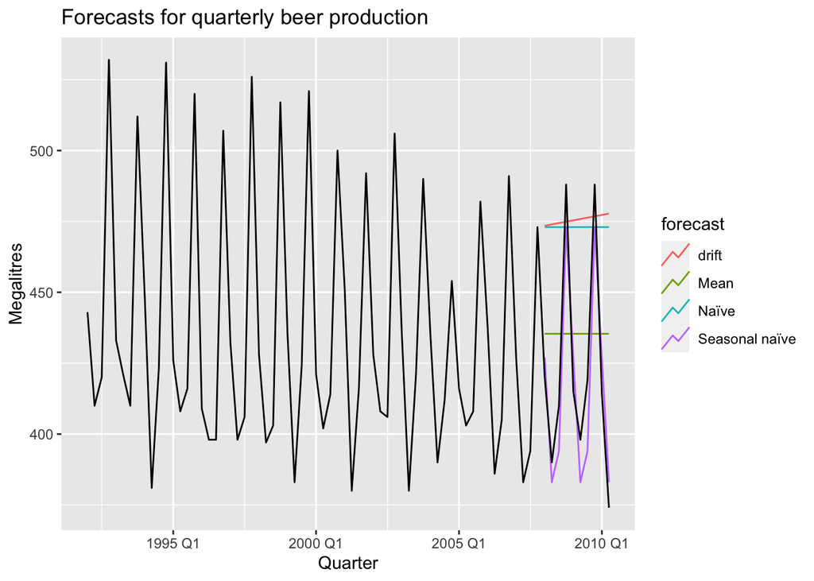

```r
recent_production <- aus_production %>%
  filter(year(Quarter) >= 1992)
beer_train <- recent_production %>%
  filter(year(Quarter) <= 2007)

beer_fit <- beer_train %>%
  model(
    Mean = MEAN(Beer),
    `Naïve` = NAIVE(Beer),
    `Seasonal naïve` = SNAIVE(Beer),
    drift = RW(Beer ~ drift())
)

beer_fc <- beer_fit %>%
  forecast(h = 10)
beer_fc %>%
  autoplot(
    aus_production %>% filter(year(Quarter) >= 1992),
    level = NULL
  ) +
  labs(
    y = "Megalitres",
    title = "Forecasts for quarterly beer production"
  ) +
  guides(colour = guide_legend(title = "forecast"))
```

```r
accuracy(beer_fc, recent_production)
```

```
## # A tibble: 4 × 10
##   .model         .type    ME  RMSE   MAE    MPE  MAPE  MASE RMSSE    ACF1
##   <chr>          <chr> <dbl> <dbl> <dbl>  <dbl> <dbl> <dbl> <dbl>   <dbl>
## 1 drift          Test  -54.0  64.9  58.9 -13.6  14.6  4.12  3.87  -0.0741
## 2 Mean           Test  -13.8  38.4  34.8  -3.97  8.28 2.44  2.29  -0.0691
## 3 Naïve          Test  -51.4  62.7  57.4 -13.0  14.2  4.01  3.74  -0.0691
## 4 Seasonal naïve Test    5.2  14.3  13.4   1.15  3.17 0.937 0.853  0.132
```

To take a non-seasonal example, consider the Google stock price. The following graph shows the closing stock prices from 2015, along with forecasts for January 2016 obtained from three different methods.

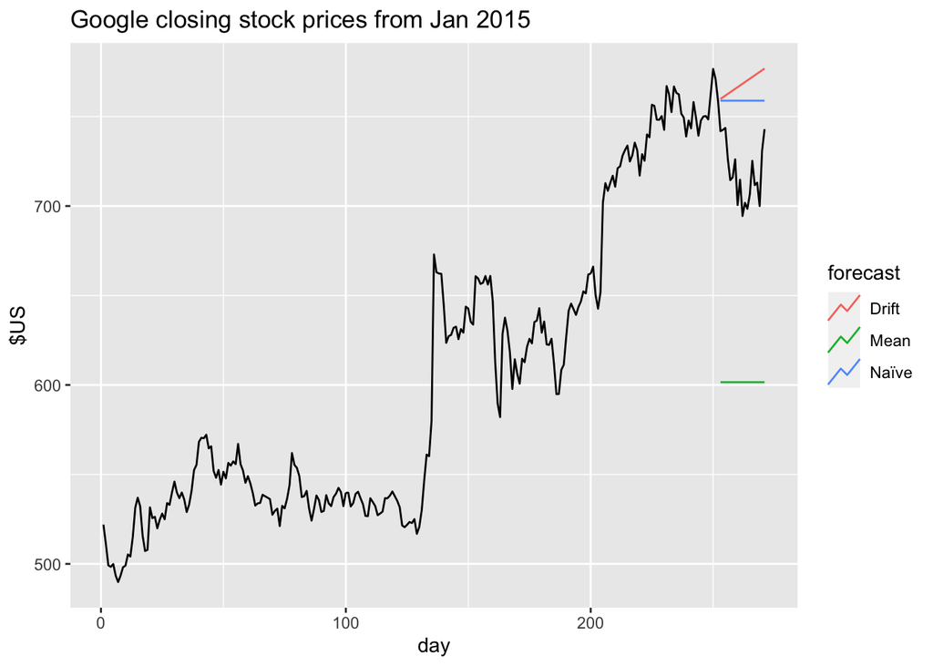

```r
google_fit <- google_2015 %>%
  model(
    Mean = MEAN(Close),
    `Naïve` = NAIVE(Close),
    Drift = RW(Close ~ drift())
)

google_fc <- google_fit %>%
  forecast(google_jan_2016)

google_fc %>%
  autoplot(bind_rows(google_2015, google_jan_2016),
    level = NULL) +
  labs(y = "$US",
       title = "Google closing stock prices from Jan 2015") +
  guides(colour = guide_legend(title = "forecast"))
```

## 5.9 Evaluating distributional forecast accuracy

## Quantile scores

Consider the Google stock price example from the previous section. Figure 5.23 shows an 80% prediction interval for the forecasts from the naïve method:

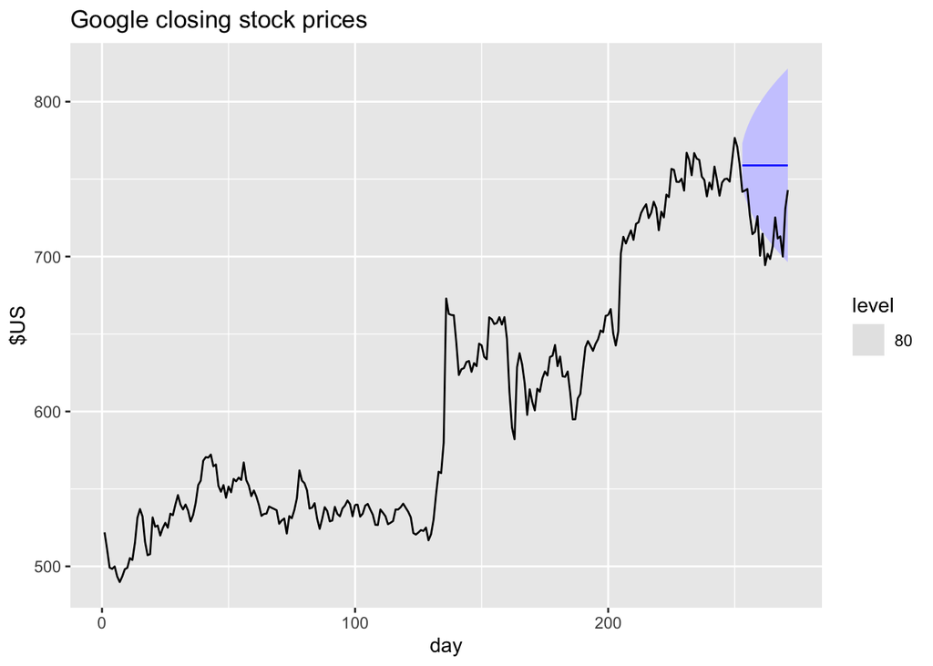

```r
google_fc %>%
  filter(.model == "Naïve") %>%
  autoplot(bind_rows(google_2015, google_jan_2016), level = 80)+
             labs(y = "$US",
                  title = "Google closing stock prices")
```

The lower limit of this prediction interval gives the 10th percentile (or 0.1 quantile) of the forecast distribution, so we would expect the actual value to lie below the lower limit about 10% of the time, and to lie above the lower limit about 90% of the time. When we compare the actual value to this percentile, we need to allow for the fact that it is more likely to be above than below.

More generally, suppose we are interested in the quantile forecast with probability $p$ at future time $t$, and let this be denoted by $f_{p,t}$. That is, we expect the observation $y_t$ to be less than $f_{p,t}$ with probability $p$. For example, the 10th percentile would be $f_{0.10,t}. If $y_t$ denotes the observation at time $t$, then the **Quantile Score** is

$$Q_{p,t} = \begin{cases}
2(1 - p) \big(f_{p,t} - y_{t}\big), & \text{if $y_{t} < f_{p,t}$}\\
2p \big(y_{t} - f_{p,t}\big), & \text{if $y_{t} \ge f_{p,t}$} \end{cases}$$

The quantile score can be interpreted like an absolute error. In fact, when p=0.5, the quantile score $Q_{0.5,t}$ is the same as the absolute error. For other values of p, the “error” ($y_t−f_{p,t}$) is weighted to take account of how likely it is to be positive or negative. If p>0.5, $Q{p,t}$ gives a heavier penalty when the observation is greater than the estimated quantile than when the observation is less than the estimated quantile. The reverse is true for p<0.5.

## Consinuous Ranked Probability Score

In the Google stock price example, we can compute the average CRPS value for all days in the test set. A CRPS value is a little like a weighted absolute error computed from the entire forecast distribution, where the weighting takes account of the probabilities.

```r
google_fc %>%
  accuracy(google_stock, list(crps = CRPS))
```

```
## # A tibble: 3 × 4
##   .model Symbol .type  crps
##   <chr>  <chr>  <chr> <dbl>
## 1 Drift  GOOG   Test   33.5
## 2 Mean   GOOG   Test   76.7
## 3 Naïve  GOOG   Test   26.5
```

## 5.10 Time series cross-validation

In the following example, we compare the accuracy obtained via time series cross-validation with the residual accuracy. The `stretch_tsibble()` function is used to create many training sets. In this example, we start with a training set of length `.init=3`, and increasing the size of successive training sets by `.step=1`.

```r
google_2015_tr <- google_2015 %>%
  stretch_tsibble(.init = 3, .step = 1) %>%
  relocate(Date, Symbol, .id)
google_2015_tr
```

```
## # A tsibble: 31,875 x 10 [1]
## # Key:       Symbol, .id [250]
##    Date       Symbol   .id  Open  High   Low Close Adj_Close  Volume   day
##    <date>     <chr>  <int> <dbl> <dbl> <dbl> <dbl>     <dbl>   <dbl> <int>
##  1 2015-01-02 GOOG       1  526.  528.  521.  522.      522. 1447600     1
##  2 2015-01-05 GOOG       1  520.  521.  510.  511.      511. 2059800     2
##  3 2015-01-06 GOOG       1  512.  513.  498.  499.      499. 2899900     3
##  4 2015-01-02 GOOG       2  526.  528.  521.  522.      522. 1447600     1
##  5 2015-01-05 GOOG       2  520.  521.  510.  511.      511. 2059800     2
##  6 2015-01-06 GOOG       2  512.  513.  498.  499.      499. 2899900     3
##  7 2015-01-07 GOOG       2  504.  504.  497.  498.      498. 2065100     4
##  8 2015-01-02 GOOG       3  526.  528.  521.  522.      522. 1447600     1
##  9 2015-01-05 GOOG       3  520.  521.  510.  511.      511. 2059800     2
## 10 2015-01-06 GOOG       3  512.  513.  498.  499.      499. 2899900     3
## # … with 31,865 more rows
```

The .id column provides a new key indicating the various training sets. The accuracy() function can be used to evaluate the forecasts accuracy across the training sets.

```r
google_2015_tr %>%
  model(RW(Close ~ drift())) %>%
  forecast(h = 1) %>%
  accuracy(google_2015)
```

```
## # A tibble: 1 × 11
##   .model           Symbol .type    ME  RMSE   MAE   MPE  MAPE  MASE RMSSE   ACF1
##   <chr>            <chr>  <chr> <dbl> <dbl> <dbl> <dbl> <dbl> <dbl> <dbl>  <dbl>
## 1 RW(Close ~ drif… GOOG   Test  0.726  11.3  7.26 0.112  1.19  1.02  1.01 0.0985
```

```r
# Training set accuracy
google_2015 %>%
  model(RW(Close ~ drift())) %>%
  accuracy()
```

```
## # A tibble: 1 × 11
##   Symbol .model     .type        ME  RMSE   MAE     MPE  MAPE  MASE RMSSE   ACF1
##   <chr>  <chr>      <chr>     <dbl> <dbl> <dbl>   <dbl> <dbl> <dbl> <dbl>  <dbl>
## 1 GOOG   RW(Close … Trai… -3.04e-14  11.1  7.16 -0.0267  1.18  1.00 0.996 0.0976
```

Completion of chapter 5!